# Prospective Ageing - Talk

This is the repo for an informal seminar I gave at the Oxford Institute of Population Ageing 21.11.2018.

It includes my first attempts at using gganimate to animate the charts and [xarinang](https://github.com/yihui/xaringan) to make the slides.

## Prospective Ageing

The talk is a descriptive one on what Prospective Age is, following Sanderson and Scherbov and what they call the [*Characteristics Approach to Population Ageing: New Measures*](http://www.iiasa.ac.at/web/home/research/researchPrograms/WorldPopulation/Reaging/Indicators.html). I then used the 10 countries represented in my audience to demonstrate the difference between restrospective and prospective measures of ageing.

## Data

The data used here is sourced directly from the [Prospective Age Dataset](https://figshare.com/articles/Prospective_Age_Dataset/6974414) figshare deposit, which I prepared in this [github repository](https://github.com/majazaloznik/ProspectiveAgeData). The underlying data is the 2017 Revision of the UN World Population Prospects.

## The gifs…

…are the best bit.

Here, for example, is the old age threshold—age at which the remaining life expectancy is 15 years—in Belarus 1980 to 2050. The lines in the background are the other nine *specially selected countries* (China, Georgia, Japan, Italy, South Korea, UK, USA, Spain & Slovenia).

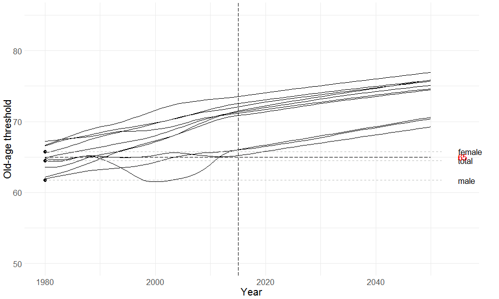

And here is the Belarussian population pyramid with the people with a remaining life expectancy of 15 years or less highlighted in yellow. This is for 1990-2040.

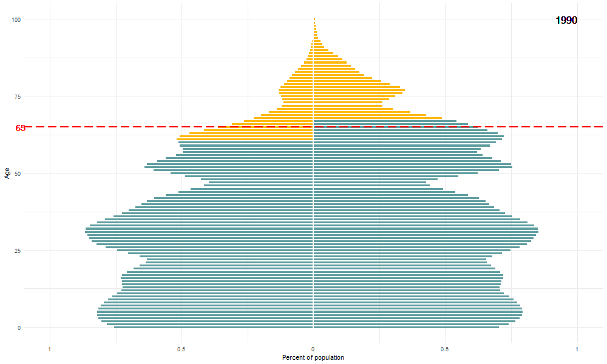

And finally, to mix it up a bit, here’s how Japan’s proportion of the population over 65 compares to the proportion of the population over the $RLE_{15}$ threhsold i.e. the proportion of people who have fewer than 15 years to live.

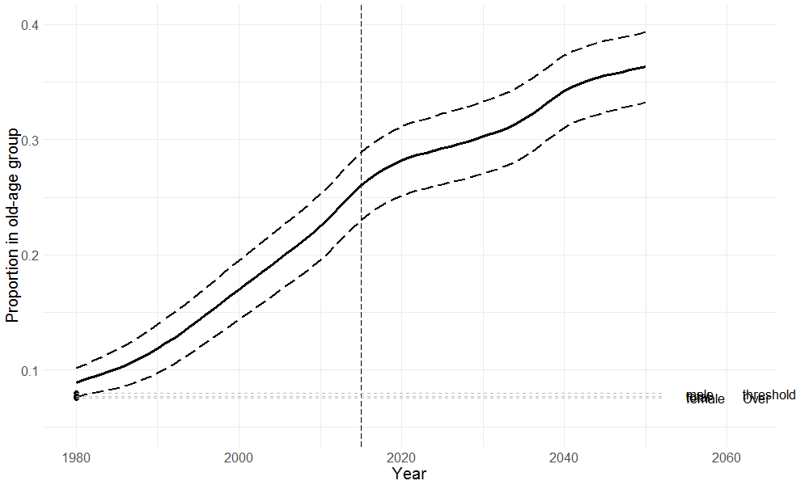

## The actual presentation

Deployed on [github pages here](https://majazaloznik.github.io/2018-prospective_ageing_talk/presentations/2018-propsective_ageing_talk.html#1).

## Authors

*Maja Z*

## Acknowledgments

- Hat tip Sanderson and Scherbov for their amazing work!